# learningAnalysis

2025-07-17

load packages

loading and tidying data

```r
# learning data
df_learn <- read.csv('~/learning.csv')
df_learn <- df_learn %>%
  mutate(condition <- ifelse(subID < 55, 'condition_80cue', 'condition_65cue'),
         cueIdx = factor(cueIdx, levels=c(3,1,2), labels=c('neutral', 'non-neutral1', 'non-neutral2')))

# estimates data
df_est <- read.csv('~/Downloads/estimates.csv') %>%
group_by(subID) %>%
  mutate(zconf = as.numeric(scale(cueConfidence))) %>%
  ungroup()

df_est$cueDiff <- df_est$subjectiveCue - df_est$trueCue

## CueCorr column
correlations <- df_est %>%
  group_by(subID) %>%
  summarise(corr = cor(trueCue, subjectiveCue, use = "complete.obs"))

df_est <- merge(df_est, correlations, by = "subID")
df_est$cueCorr <- df_est$corr
df_est$corr <- NULL

## conditions column
df_est$condition <- ifelse(df_est$subID < 55, '80/50_cue', '65/50_cue')

# inference data
df_inf <- read.csv('~/Downloads/inference_test.csv')
```

# slopes of regression lines during learning

## trueCue as predictor for aggregated data

```r
# model
model1 <- lm(formula = imgLockedRT ~ trial * trueCue, data = df_learn)
summary(model1)
```

```
##
## Call:
## lm(formula = imgLockedRT ~ trial * trueCue, data = df_learn)
##
## Residuals:
##     Min      1Q  Median      3Q     Max
## -1.5238 -0.4335  0.1634  0.3669  1.3656
##
## Coefficients:
##                 Estimate Std. Error t value Pr(>|t|)
## (Intercept)    0.2647426  0.0467554   5.662 1.59e-08 ***
## trial         -0.0004987  0.0002856  -1.746   0.0809 .
## trueCue       -0.0037133  0.0700108  -0.053   0.9577
## trial:trueCue -0.0001009  0.0004052  -0.249   0.8034
## ---
## Signif. codes:  0 '***' 0.001 '**' 0.01 '*' 0.05 '.' 0.1 ' ' 1
##
## Residual standard error: 0.4788 on 4494 degrees of freedom
##   (114 observations deleted due to missingness)
## Multiple R-squared:  0.0222, Adjusted R-squared:  0.02154
## F-statistic:    34 on 3 and 4494 DF,  p-value: < 2.2e-16
```

```r
# model
model2 <- lm(accuracy ~ trial * trueCue, data = df_learn)
summary(model2)
```

```
##
## Call:
## lm(formula = accuracy ~ trial * trueCue, data = df_learn)
##
## Residuals:
##     Min      1Q  Median      3Q     Max
## -0.8322  0.1683  0.1865  0.2391  0.3073
##
## Coefficients:
##                 Estimate Std. Error t value Pr(>|t|)
## (Intercept)    0.4597786  0.0405480  11.339  < 2e-16 ***
## trial          0.0003456  0.0002485   1.391    0.164
## trueCue        0.4656283  0.0607955   7.659 2.27e-14 ***
## trial:trueCue -0.0005597  0.0003518  -1.591    0.112
## ---
## Signif. codes:  0 '***' 0.001 '**' 0.01 '*' 0.05 '.' 0.1 ' ' 1
##
## Residual standard error: 0.4223 on 4608 degrees of freedom
## Multiple R-squared:  0.01518,    Adjusted R-squared:  0.01454
## F-statistic: 23.68 on 3 and 4608 DF,  p-value: 3.31e-15
```

Questions/Ideas: Does the continued exposure to cues over trials allow everyone to reach the similar levels of accuracy?

## cueIdx as predictor

```r
# model
model3 <- lm(formula = imgLockedRT ~ trial * cueIdx, data = df_learn)
summary(model3)
```

```
##
## Call:
## lm(formula = imgLockedRT ~ trial * cueIdx, data = df_learn)
##
## Residuals:
##     Min      1Q  Median      3Q     Max
## -1.5230 -0.4311  0.1601  0.3632  1.2845
##
## Coefficients:
##                            Estimate Std. Error t value Pr(>|t|)
## (Intercept)               2.850e-01  1.517e-02  18.782  < 2e-16 ***
## trial                    -5.984e-04  9.689e-05  -6.176 7.15e-10 ***
## cueIdxnon-neutral1       -4.910e-02  2.138e-02  -2.296  0.02170 *
## cueIdxnon-neutral2       -1.758e-02  2.139e-02  -0.822  0.41140
## trial:cueIdxnon-neutral1  3.675e-04  1.374e-04   2.674  0.00752 **
## trial:cueIdxnon-neutral2 -2.887e-04  1.379e-04  -2.093  0.03637 *
## ---
## Signif. codes:  0 '***' 0.001 '**' 0.01 '*' 0.05 '.' 0.1 ' ' 1
##
## Residual standard error: 0.4774 on 4492 degrees of freedom
##   (114 observations deleted due to missingness)
## Multiple R-squared:  0.02841,    Adjusted R-squared:  0.02733
## F-statistic: 26.27 on 5 and 4492 DF,  p-value: < 2.2e-16
```

- Main effects: non-neutral cue 1 and 2 both lead to faster RTs than the neutral cue, with cueIdx 1 being faster than cueIdx 2.
- Interactions: Difference! With cueIdx 1, the advantage on RTs decreases over trials. Counteracting the main trial effect. But with cueIdx 2 the advantage on RTs increases over trials.
- Non neutral cues help reduce uncertainty in making the decision but the advantage diminishes over trials as participants learned to use neutral cue.
  - This shows that some cues (1) help reduce uncertainty early on, but become less needed while other cues (2) become more useful.

Questions/Ideas: What makes 1 less useful over time and 2 more useful over time if they are both non-neutral??

```r
# model
model4 <- lm(formula = accuracy ~ trial * cueIdx, data = df_learn)
summary(model4)
```

```
##
## Call:
## lm(formula = accuracy ~ trial * cueIdx, data = df_learn)
##
## Residuals:
##     Min      1Q  Median      3Q     Max
## -0.8989  0.1376  0.2146  0.2786  0.3146
##
## Coefficients:
##                            Estimate Std. Error t value Pr(>|t|)
## (Intercept)               7.171e-01  1.321e-02  54.272  < 2e-16 ***
## trial                    -3.794e-06  8.505e-05  -0.045 0.964418
## cueIdxnon-neutral1        6.280e-02  1.866e-02   3.366 0.000769 ***
## cueIdxnon-neutral2        7.288e-02  1.865e-02   3.908 9.42e-05 ***
## trial:cueIdxnon-neutral1  1.822e-04  1.203e-04   1.515 0.129880
## trial:cueIdxnon-neutral2 -1.560e-04  1.199e-04  -1.301 0.193342
## ---
## Signif. codes:  0 '***' 0.001 '**' 0.01 '*' 0.05 '.' 0.1 ' ' 1
##
## Residual standard error: 0.424 on 4606 degrees of freedom
## Multiple R-squared:  0.007921,   Adjusted R-squared:  0.006844
## F-statistic: 7.355 on 5 and 4606 DF,  p-value: 7.072e-07
```

- Main effects: both cues lead to increase in accuracy compared to neutral cues.(positive slopes + significant)
- Interactions: cueIdx 1 has accuracy advantages that slightly increase overtime, while cueIdx 2 accuracy advantages slightly decrease overtime.(not significant tho)
- Both non-neutral cues helped accuracy compared to neutral 3, but the advantages didn’t change much over trials.

Question/Ideas: Similar to RT one, what makes one cueIdx increase over trials but not the other?

## individual slopes

```r
trueCue_stats <- list()
cueIdx_stats <- list()

for(sub_id in unique(df_learn$subID)) {
  df_sub <- df_learn[df_learn$subID == sub_id, ]
  # the tidy/dplyr version
  # df_sub <- df_learn %>% filter(subID == sub_id)
  model_sub <- lm(imgLockedRT ~ trial * trueCue, data = df_sub)
  model_cat <- lm(imgLockedRT ~ trial * cueIdx, data = df_sub)

  # Get tidy results with coefficients, t-values, and p-values
  tidy_true <- tidy(model_sub)
  tidy_cueIdx <- tidy(model_cat)

  # Add subject ID
  tidy_true$subID <- sub_id
  tidy_cueIdx$subID <- sub_id

  # Add to lists
  trueCue_stats[[length(trueCue_stats) + 1]] <- tidy_true
  cueIdx_stats[[length(cueIdx_stats) + 1]] <- tidy_cueIdx
}

# Combine all results
df_trueCue_stats <- bind_rows(trueCue_stats)
df_cueIdx_stats <- bind_rows(cueIdx_stats)

# Reorder columns to put subID first
df_trueCue_stats <- df_trueCue_stats[, c("subID", "term", "estimate", "std.error", "statistic", "p.value")]
df_cueIdx_stats <- df_cueIdx_stats[, c("subID", "term", "estimate", "std.error", "statistic", "p.value")]


# Write  results
write.csv(df_trueCue_stats, "trueCue_detailed_stats.csv", row.names = FALSE)
write.csv(df_cueIdx_stats, "cueIdx_detailed_stats.csv", row.names = FALSE)
```

## plots of RTs across learning: trueCue

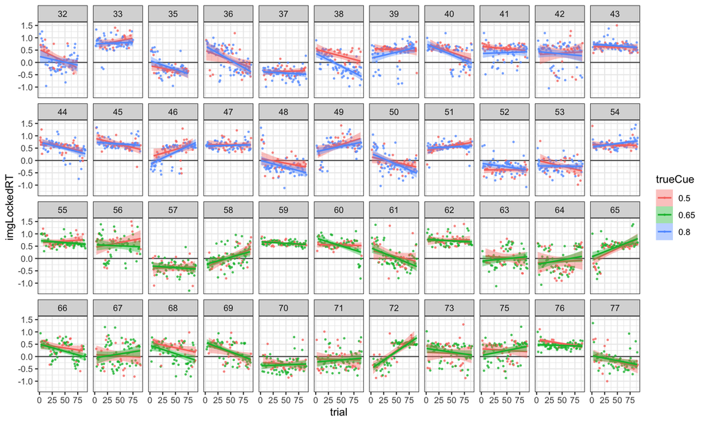

```r
df_learn %>%
  filter(trial < 91) %>%
  mutate(trueCue = factor(trueCue)) %>%
  ggplot(aes(x=trial, y=imgLockedRT, color=trueCue, fill=trueCue)) +
  theme_bw() + facet_wrap(~subID, nrow=4) + geom_hline(yintercept = 0, color='gray30') +
  geom_point(size=0.5, alpha=0.7) + stat_smooth(method='lm', linewidth=0.75)
```

```r
df_trueCue_stats %>%
  filter(term == 'trial' | term == 'trueCue' | term == 'trial:trueCue') %>%
  select(subID, term, estimate, p.value) %>%
  pivot_wider(id_cols=subID, names_from=term, values_from=c(estimate, p.value)) %>%
  round(., digits=3)
```

```
## # A tibble: 44 × 7
##    subID estimate_trial estimate_trueCue `estimate_trial:trueCue` p.value_trial
##    <dbl>          <dbl>            <dbl>                    <dbl>         <dbl>
##  1    32         -0.001           -0.259                    0.001         0.02
##  2    33          0.009            0.195                   -0.01          0.294
##  3    35          0.001            0.691                   -0.011         0.863
##  4    36         -0.001            0.612                   -0.013         0.882
##  5    37          0.004           -0.456                    0.005         0.216
##  6    38          0.003           -0.546                   -0.017         0.642
##  7    39         -0.011           -1.33                     0.02          0.19
##  8    40         -0.005           -0.092                   -0.005         0.507
##  9    41         -0.006           -0.953                    0.009         0.362
## 10    42          0.007            0.429                   -0.011         0.548
## # ℹ 34 more rows
## # ℹ 2 more variables: p.value_trueCue <dbl>, `p.value_trial:trueCue` <dbl>
```

## plots of RTs across learning: cueIdx

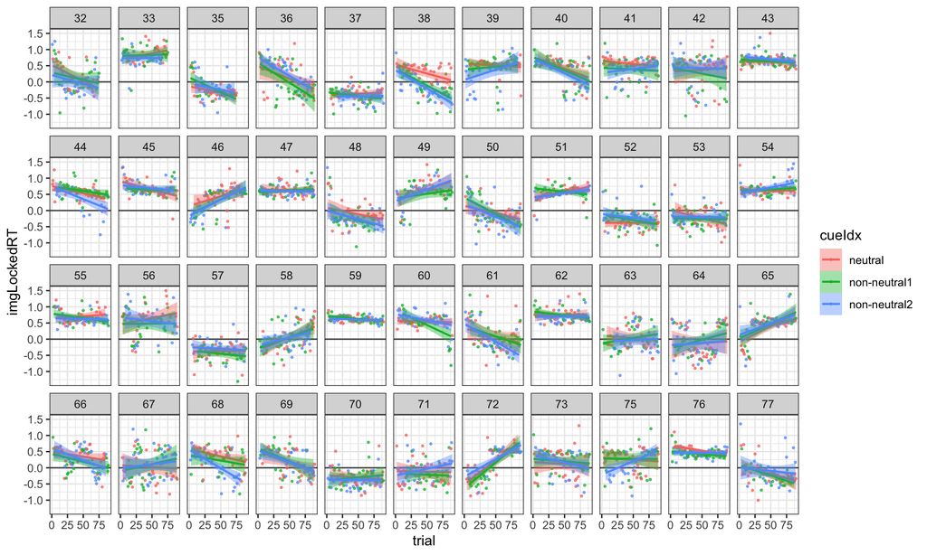

```r
df_learn %>%
  filter(trial < 91) %>%
  ggplot(aes(x=trial, y=imgLockedRT, color=cueIdx, fill=cueIdx)) +
  theme_bw() + facet_wrap(~subID, nrow=4) + geom_hline(yintercept = 0, color='gray30') +
  geom_point(size=0.5, alpha=0.7) + stat_smooth(method='lm', linewidth=0.75)
```

```r
df_cueIdx_stats %>%
  filter(term == 'trial' | term == 'cueIdx' | term == 'trial:cueIdx') %>%
  select(subID, term, estimate, p.value) %>%
  pivot_wider(id_cols=subID, names_from=term, values_from=c(estimate, p.value)) %>%
  round(., digits=3)
```

```
## # A tibble: 44 × 3
##    subID estimate_trial p.value_trial
##    <dbl>          <dbl>         <dbl>
##  1    32         -0.001         0
##  2    33          0.004         0.195
##  3    35         -0.004         0.182
##  4    36         -0.008         0.008
##  5    37          0.006         0
##  6    38         -0.005         0.015
##  7    39         -0.001         0.691
##  8    40         -0.007         0.006
##  9    41         -0.002         0.435
## 10    42          0.001         0.738
## # ℹ 34 more rows
```

## correlations between trueCue RT slopes during learning & explicit report behavior

```r
trueCue_fits <- df_trueCue_stats %>% filter(subID != 33)
cueIdx_fits <- df_cueIdx_stats %>% filter(subID != 33)

trueCue_fitsWider <- trueCue_fits %>% pivot_wider(id_cols = subID, names_from = term, values_from=c(estimate, statistic, p.value))
# ^ the pivot from earlier

#diff of explicit reports b/w neutral and non-neutral cues
trueCue_diffValues <- df_est %>%
  mutate(trueCue = ifelse(trueCue==0.5, 'neutral', 'informative')) %>%
  group_by(subID, trueCue, condition) %>%
  summarise(subjectiveCue = mean(subjectiveCue, na.rm=T),
            cueConfidence = mean(cueConfidence, na.rm=T),
            zConfidence = mean(zconf, na.rm=T),
            cueDiff = mean(cueDiff, na.rm=T),
            .groups = 'keep')%>%
  pivot_wider(id_cols=subID, values_from=c(subjectiveCue, cueConfidence, zConfidence, cueDiff), names_from=trueCue) %>%
  summarise(subjectiveCueDiff = subjectiveCue_informative - subjectiveCue_neutral,
            cueConfidenceDiff = cueConfidence_informative - cueConfidence_neutral,
            zConfidenceDiff = zConfidence_informative - zConfidence_neutral,
            cueDiffDiff = cueDiff_informative - cueDiff_neutral)

#merge differences w/ trial:trueCue estimate
trueCue_fitsWider %>% select(subID, `estimate_trial:trueCue`) %>%
  left_join(., trueCue_diffValues, by='subID') %>%
  summarise(subjectiveCue_corr = cor(subjectiveCueDiff, `estimate_trial:trueCue`, use= 'complete.obs'),
            cueConfidence_corr = cor(cueConfidenceDiff, `estimate_trial:trueCue`, use= 'complete.obs'),
            zConfidence_corr = cor(zConfidenceDiff, `estimate_trial:trueCue`, use= 'complete.obs'),
            cueDiff_corr = cor(cueDiffDiff, `estimate_trial:trueCue`, use= 'complete.obs'))
```

```
## # A tibble: 1 × 4
##   subjectiveCue_corr cueConfidence_corr zConfidence_corr cueDiff_corr
##                <dbl>              <dbl>            <dbl>        <dbl>
## 1             -0.146             -0.197           -0.155       -0.160
```

```r
#df with just cueCorrs and subID
cueCorrs <- df_est %>% group_by(subID) %>% filter(subID !=33)%>% select(cueCorr) %>% unique()
cor(trueCue_fitsWider$`estimate_trial:trueCue`, cueCorrs$cueCorr)
```

```
## [1] 0.00148833
```

## correlation between cueIdx RTs slopes during learning & explicit report behavior

```r
# cueIdx_fitsWider <- cueIdx_fits %>% pivot_wider(id_cols = subID, names_from = term, values_from=c(estimate, statistic, p.value))
```

## individual correlations with different outcome variables of interest

```r
coef_trueCue <- df_trueCue_stats %>%
  select(subID, term, estimate) %>%
  pivot_wider(names_from = term, values_from = estimate)

coef_cueIdx <- df_cueIdx_stats %>%
  select(subID, term, estimate) %>%
  pivot_wider(names_from = term, values_from = estimate)

trueCue_full <- inner_join(coef_trueCue, df_est, by = "subID")
cueIdx_full  <- inner_join(coef_cueIdx,  df_est, by = "subID")

cor_test_matrix <- function(full_df, outcome_vars, exclude = "subID") {
  coef_vars <- setdiff(names(full_df), c(exclude, outcome_vars))

  #numeric columns
  full_df[coef_vars] <- lapply(full_df[coef_vars], function(x) as.numeric(as.character(x)))
  full_df[outcome_vars] <- lapply(full_df[outcome_vars], function(x) as.numeric(as.character(x)))

  cor_matrix <- matrix(NA, nrow = length(coef_vars), ncol = length(outcome_vars),
                       dimnames = list(coef_vars, outcome_vars))
  p_matrix <- cor_matrix

  for (coef in coef_vars) {
    for (outcome in outcome_vars) {
      x <- full_df[[coef]]
      y <- full_df[[outcome]]
      valid <- complete.cases(x, y)
      if (sum(valid) >= 3) {
        test <- cor.test(x[valid], y[valid])
        cor_matrix[coef, outcome] <- test$estimate
        p_matrix[coef, outcome] <- test$p.value
      }
    }
  }

  list(correlation = cor_matrix, p.value = p_matrix)
}

outcome_vars <- c("cueDiff", "cueCorr", "cueConfidence", "subjectiveCue")

trueCue_corrs <- cor_test_matrix(trueCue_full, outcome_vars)
cueIdx_corrs  <- cor_test_matrix(cueIdx_full,  outcome_vars)
trueCue_corrs$correlation     # Correlations: trueCue model
```

```
##                        cueDiff       cueCorr cueConfidence subjectiveCue
## (Intercept)        0.013256274  3.573054e-02   -0.11092713    0.07338393
## trial             -0.066803777 -1.317347e-02    0.07928326   -0.11188944
## trueCue.x         -0.095795229 -1.936173e-01    0.06361611   -0.13031148
## trial:trueCue      0.061009003  1.488330e-03   -0.12740921    0.08358585
## block                       NA            NA            NA            NA
## cueName                     NA            NA            NA            NA
## cueIdx             0.459681338  0.000000e+00   -0.17233412   -0.16626373
## congImgIdx         0.056972460  0.000000e+00    0.12273615    0.06615222
## RT                -0.006781363 -1.968500e-03   -0.13133500    0.07858017
## sliderValue       -0.007672209 -1.650608e-03    0.08396841    0.03573919
## confRT             0.178354948  7.413591e-02   -0.09889058    0.12242919
## trueCue.y         -0.623682233  9.140535e-02    0.26043234    0.20820413
## imgIdx_subjective  0.015144022 -3.395194e-02    0.10085105    0.06134365
## subjectiveCongCue  0.471346788  2.006466e-01    0.39610724    0.68105183
## zconf              0.090874132  9.864210e-17    0.77096633    0.42342438
## condition                   NA            NA            NA            NA
```

```r
trueCue_corrs$p.value         # P-values
```

```
##                        cueDiff    cueCorr cueConfidence subjectiveCue
## (Intercept)       8.800853e-01 0.68768450  2.107546e-01  4.030276e-01
## trial             4.466167e-01 0.88220704  3.717892e-01  2.014964e-01
## trueCue.x         2.745473e-01 0.02791257  4.738473e-01  1.364128e-01
## trial:trueCue     4.871048e-01 0.98664431  1.501856e-01  3.406594e-01
## block                       NA         NA            NA            NA
## cueName                     NA         NA            NA            NA
## cueIdx            2.945596e-08 1.00000000  5.082849e-02  5.673588e-02
## congImgIdx        5.980298e-01 1.00000000  2.602437e-01  5.402988e-01
## RT                9.399260e-01 0.98254674  1.459521e-01  3.817791e-01
## sliderValue       9.304252e-01 0.98518825  3.441041e-01  6.841280e-01
## confRT            4.074768e-02 0.40373115  2.648572e-01  1.619652e-01
## trueCue.y         1.373312e-15 0.30290728  2.875283e-03  1.659107e-02
## imgIdx_subjective 8.668791e-01 0.70699934  2.690342e-01  4.967621e-01
## subjectiveCongCue 1.721911e-08 0.02370553  4.406782e-06  6.649987e-19
## zconf             3.565570e-01 1.00000000  6.642005e-22  6.780613e-06
## condition                   NA         NA            NA            NA
```

```r
cueIdx_corrs$correlation      # Correlations: cueIdx model
```

```
##                               cueDiff       cueCorr cueConfidence subjectiveCue
## (Intercept)              -0.071228104 -1.327081e-01   -0.09937985   -0.01722095
## trial                    -0.032193372 -2.383430e-02   -0.05304333   -0.08475462
## cueIdxnon-neutral1       -0.106278241 -8.955934e-02    0.04661636   -0.10709758
## cueIdxnon-neutral2       -0.050418452 -2.347794e-01    0.05443765   -0.12414853
## trial:cueIdxnon-neutral1  0.101221814 -6.054530e-02   -0.12027892    0.06491765
## trial:cueIdxnon-neutral2  0.064807323 -7.174678e-04   -0.10843519    0.10901121
## block                              NA            NA            NA            NA
## cueName                            NA            NA            NA            NA
## cueIdx                    0.459681338  0.000000e+00   -0.17233412   -0.16626373
## congImgIdx                0.056972460  0.000000e+00    0.12273615    0.06615222
## RT                       -0.006781363 -1.968500e-03   -0.13133500    0.07858017
## sliderValue              -0.007672209 -1.650608e-03    0.08396841    0.03573919
## confRT                    0.178354948  7.413591e-02   -0.09889058    0.12242919
## trueCue                  -0.623682233  9.140535e-02    0.26043234    0.20820413
## imgIdx_subjective         0.015144022 -3.395194e-02    0.10085105    0.06134365
## subjectiveCongCue         0.471346788  2.006466e-01    0.39610724    0.68105183
## zconf                     0.090874132  9.864210e-17    0.77096633    0.42342438
## condition                          NA            NA            NA            NA
```

```r
cueIdx_corrs$p.value          # P-values
```

```
##                               cueDiff     cueCorr cueConfidence subjectiveCue
## (Intercept)              4.170231e-01 0.133810649  2.624888e-01  8.446208e-01
## trial                    7.140288e-01 0.788615559  5.504987e-01  3.339267e-01
## cueIdxnon-neutral1       2.251800e-01 0.312817469  5.998669e-01  2.216043e-01
## cueIdxnon-neutral2       5.658868e-01 0.007402587  5.400553e-01  1.561076e-01
## trial:cueIdxnon-neutral1 2.481486e-01 0.495495240  1.745450e-01  4.595830e-01
## trial:cueIdxnon-neutral2 4.603478e-01 0.993561499  2.212505e-01  2.134102e-01
## block                              NA          NA            NA            NA
## cueName                            NA          NA            NA            NA
## cueIdx                   2.945596e-08 1.000000000  5.082849e-02  5.673588e-02
## congImgIdx               5.980298e-01 1.000000000  2.602437e-01  5.402988e-01
## RT                       9.399260e-01 0.982546739  1.459521e-01  3.817791e-01
## sliderValue              9.304252e-01 0.985188250  3.441041e-01  6.841280e-01
## confRT                   4.074768e-02 0.403731154  2.648572e-01  1.619652e-01
## trueCue                  1.373312e-15 0.302907284  2.875283e-03  1.659107e-02
## imgIdx_subjective        8.668791e-01 0.706999345  2.690342e-01  4.967621e-01
## subjectiveCongCue        1.721911e-08 0.023705529  4.406782e-06  6.649987e-19
## zconf                    3.565570e-01 1.000000000  6.642005e-22  6.780613e-06
## condition                          NA          NA            NA            NA
```

```r
# Save correlation matrices
# write.csv(trueCue_corrs$correlation, "trueCue_correlations_matrix.csv", row.names = TRUE)
# write.csv(cueIdx_corrs$correlation,  "cueIdx_correlations_matrix.csv",  row.names = TRUE)

# Save p-value matrices
# write.csv(trueCue_corrs$p.value, "trueCue_pvalues_matrix.csv", row.names = TRUE)
# write.csv(cueIdx_corrs$p.value,  "cueIdx_pvalues_matrix.csv",  row.names = TRUE)
```

## heatmap of correlations

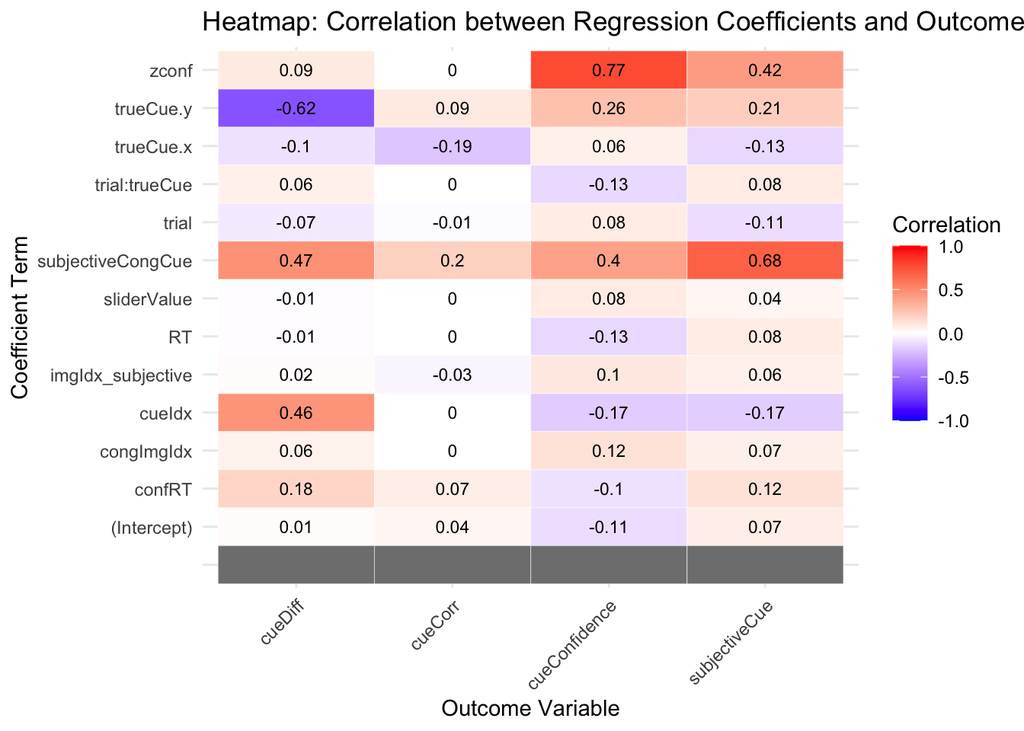

```r
#trueCue
trueCue_matrix <- read.csv("trueCue_correlations_matrix.csv", row.names = 1)
melted_df <- melt(as.matrix(trueCue_matrix)) %>%
  transform(Var1 = gsub("cueName|block|condition", "", Var1)) %>%
  transform(Var1 = trimws(Var1))

ggplot(melted_df, aes(x = Var2, y = Var1, fill = value)) +
  geom_tile(color = "white") +
  geom_text(aes(label = round(value, 2)), color = "black", size = 3)  +
  scale_fill_gradient2(low = "blue", mid = "white", high = "red",
                       midpoint = 0, limit = c(-1, 1), space = "Lab",
                       name = "Correlation") +
  theme_minimal() +
  labs(title = "Heatmap: Correlation between Regression Coefficients and Outcomes",
       x = "Outcome Variable", y = "Coefficient Term") +
  theme(axis.text.x = element_text(angle = 45, hjust = 1))
```

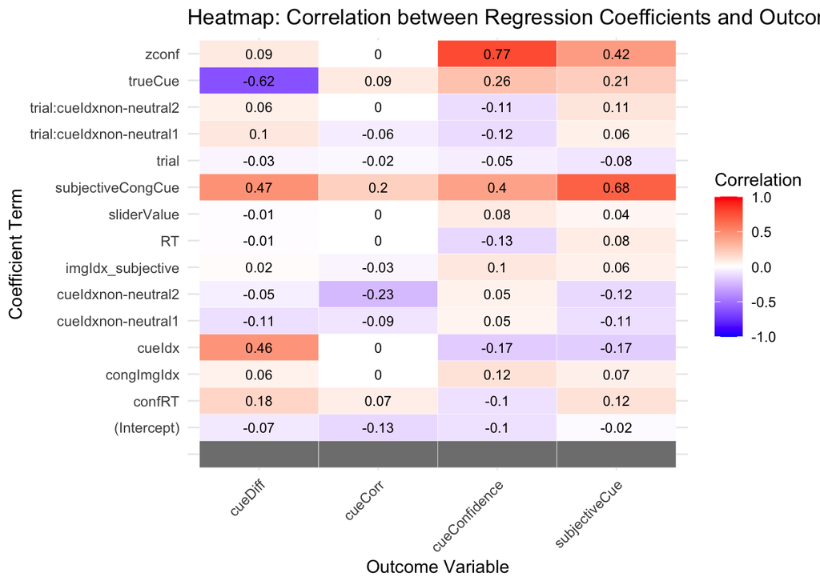

```r
#cueIdx
cueIdx_matrix <- read.csv("cueIdx_correlations_matrix.csv", row.names = 1)
melted_df2 <- melt(as.matrix(cueIdx_matrix))%>%
  transform(Var1 = gsub("cueName|block|condition", "", Var1)) %>%
  transform(Var1 = trimws(Var1))

ggplot(melted_df2, aes(x = Var2, y = Var1, fill = value)) +
  geom_tile(color = "white") +
  geom_text(aes(label = round(value, 2)), color = "black", size = 3)  +
  scale_fill_gradient2(low = "blue", mid = "white", high = "red",
                       midpoint = 0, limit = c(-1, 1), space = "Lab",
                       name = "Correlation") +
  theme_minimal() +
  labs(title = "Heatmap: Correlation between Regression Coefficients and Outcomes",
       x = "Outcome Variable", y = "Coefficient Term") +
  theme(axis.text.x = element_text(angle = 45, hjust = 1))
```

# correlation over all

aggregate datasets merging datasets by subject ( thought it would be interesting to compare variables in different stages of testing)

```r
df_est_agg <- df_est %>%
  group_by(subID) %>%
  summarise(
    subjectiveCue = mean(subjectiveCue, na.rm = TRUE),
    cueConfidence = mean(cueConfidence, na.rm = TRUE),
    cueCorr = first(cueCorr),
    cueDiff = mean(cueDiff, na.rm = TRUE),
    .groups = 'drop'
  )

#df_inf aggregate
df_inf_agg <- df_inf %>%
  group_by(subID) %>%
  summarise(
    inference_RT = mean(RT, na.rm = TRUE),
    confidence_rating = mean(confidence, na.rm = TRUE),
    confidence_RT = mean(confRT, na.rm = TRUE),
    .groups = 'drop'
  )

combined_data <- df_est_agg %>%
  full_join(df_inf_agg, by = "subID")
```

## correlation martix

```r
# Select variables
outcome_vars <- combined_data %>%
  select(subjectiveCue, cueConfidence, cueDiff, cueCorr,
         inference_RT, confidence_rating, confidence_RT)

# Correlation matrix
cor_matrix <- cor(outcome_vars, use = "complete.obs")

print(cor_matrix)
```

```
##                   subjectiveCue cueConfidence     cueDiff     cueCorr
## subjectiveCue         1.0000000    0.28725769  0.85345277  0.18605658
## cueConfidence         0.2872577    1.00000000  0.18214606  0.23693436
## cueDiff               0.8534528    0.18214606  1.00000000  0.04259397
## cueCorr               0.1860566    0.23693436  0.04259397  1.00000000
## inference_RT          0.2052914   -0.13352559  0.13538485  0.26378477
## confidence_rating     0.1164894    0.03263099  0.08068766 -0.33245834
## confidence_RT        -0.1667606   -0.24846736 -0.15219139 -0.06862055
##                   inference_RT confidence_rating confidence_RT
## subjectiveCue       0.20529141        0.11648940   -0.16676058
## cueConfidence      -0.13352559        0.03263099   -0.24846736
## cueDiff             0.13538485        0.08068766   -0.15219139
## cueCorr             0.26378477       -0.33245834   -0.06862055
## inference_RT        1.00000000       -0.09560007    0.38472356
## confidence_rating  -0.09560007        1.00000000   -0.18227113
## confidence_RT       0.38472356       -0.18227113    1.00000000
```

```r
#compute p vals
p_matrix <- outcome_vars %>%
  as.matrix() %>%
  rcorr()
```

## correlation map

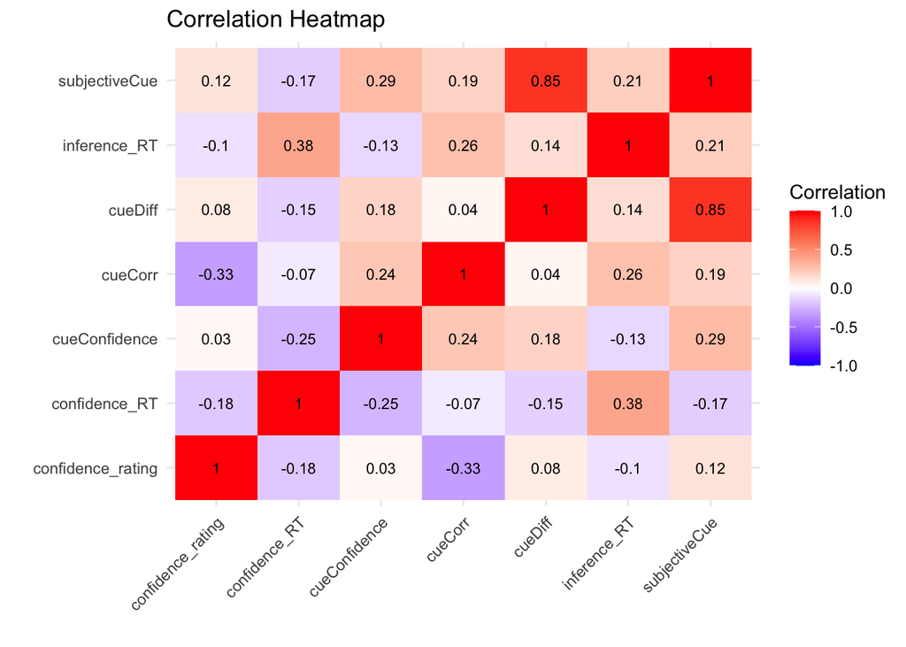

```r
# Convert correlation matrix to long format
cor_melted <- data.frame(
  Var1 = rep(rownames(cor_matrix), ncol(cor_matrix)),
  Var2 = rep(colnames(cor_matrix), each = nrow(cor_matrix)),
  value = as.vector(cor_matrix)
)

# Create heatmap
ggplot(cor_melted, aes(x = Var1, y = Var2, fill = value)) +
  geom_tile() +
  geom_text(aes(label = round(value, 2)), color = "black", size = 3) +
  scale_fill_gradient2(low = "blue", high = "red", mid = "white",
                       midpoint = 0, limit = c(-1, 1), name = "Correlation") +
  theme_minimal() +
  theme(axis.text.x = element_text(angle = 45, hjust = 1)) +
  labs(title = "Correlation Heatmap", x = "", y = "")
```